# Complex functions: worked solutions

PCB 6455 / BSC 4933: Biometry | Lecture 16

Dr. Brian Maitner

## How to use this

The code from Lecture 16, filled in, with the numbers it produces.

Optimizers are numerical, so your last decimal place may differ from mine. Anything beyond that is worth asking about.

## Setting up

```r
bbs <- read.csv("https://github.com/bmaitner/biometry_course/raw/refs/heads/main/data/BBS/FL_BBS.csv")

n_routes_by_year <- tapply(bbs$Route, bbs$Year, function(x){ length(unique(x)) })

bob_all <- bbs[bbs$Scientific_Name == "Colinus virginianus", ]
n_occ_by_year <- tapply(bob_all$Route, bob_all$Year, function(x){ length(unique(x)) })

occ <- data.frame(year = as.numeric(names(n_routes_by_year)),
                  n_routes = as.vector(n_routes_by_year),
                  n_occupied = as.vector(n_occ_by_year))

occ <- occ[occ$n_routes > 10, ]
occ$elapsed <- occ$year - min(occ$year)

c(rows = nrow(occ), first = min(occ$year), last = max(occ$year))
```

```
 rows first  last
   23  1997  2019
```

## The one-number answer

```r
const_nll <- function(p){
  -sum(dbinom(occ$n_occupied, size = occ$n_routes, prob = p, log = TRUE))
}

const_fit <- optimize(const_nll, interval = c(0, 1))

c(p = const_fit$minimum, nll = const_fit$objective)
```

```
         p        nll
 0.7855348 79.9088273
```

Which is exactly the pooled proportion:

```r
sum(occ$n_occupied) / sum(occ$n_routes)
```

```
[1] 0.7855491
```

## Why the straight line failed

The error was not your typing. At the starting values `a = 0.5` and `b = 0.05`, the last year gives

```r
0.5 + 0.05 * 22
```

```
[1] 1.6
```

and a probability of 1.6 is not a probability:

```r
dbinom(52, size = 71, prob = 1.6, log = TRUE)
```

```
[1] NaN
```

`optim()` cannot compare `NaN` with anything, so it stops before it starts. Any unbounded line will eventually do this. That is what the logit fixes.

## Your turn 1: fitting the decline

The two pieces you had to supply were the **body** and the **call**:

```r
occ_nll <- function(a, b){
  p <- plogis(a + b * occ$elapsed)
  -sum(dbinom(occ$n_occupied, size = occ$n_routes, prob = p, log = TRUE))
}

fit_occ <- optim(par = c(a = 2, b = -0.05),
                 fn = function(p){
                   occ_nll(p["a"], p["b"])
                 },
                 method = "BFGS")

round(fit_occ$par, 4)
```

```
      a       b
 2.0177 -0.0619
```

```r
round(fit_occ$value, 2)
```

```
[1] 56.69
```

## What those two numbers mean

```r
unname(plogis(fit_occ$par["a"]))                          # occupancy in 1997
```

```
[1] 0.8826417
```

```r
unname(plogis(fit_occ$par["a"] + 22 * fit_occ$par["b"]))  # occupancy in 2019
```

```
[1] 0.6583445
```

```r
unname(exp(fit_occ$par["b"]))                             # odds multiplier per year
```

```
[1] 0.9399785
```

`b` is a change in **log odds**, not in probability.

- 1997 odds: 0.88 / 0.12 = about 7.5 to 1
- multiply by 0.94, twenty-two times: 1.92 to 1
- which is a probability of about 0.66

Reporting `b = -0.062` as “a 6% decline in occupancy” is the common mistake. It is a 6% decline in the **odds**.

## Checking it by eye

```r
plot(occ$elapsed, occ$n_occupied / occ$n_routes, pch = 16,
     ylim = c(0, 1), xlab = "years since 1997", ylab = "proportion occupied")

elapsed_seq <- 0:22

lines(elapsed_seq,
      plogis(fit_occ$par["a"] + fit_occ$par["b"] * elapsed_seq),
      col = "red", lwd = 3)
```

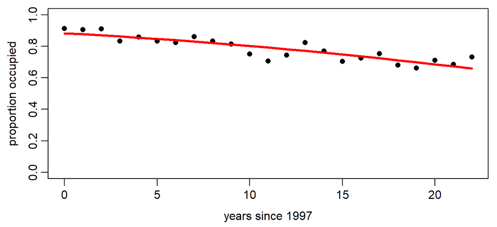

## The `mle2()` route, and `glm()`

```r
library(bbmle)

occ_nll2 <- function(params, n_occupied, n_routes, elapsed){
  p <- plogis(params[1] + params[2] * elapsed)
  -sum(dbinom(n_occupied, size = n_routes, prob = p, log = TRUE))
}

parnames(occ_nll2) <- c("a", "b")

m_occ <- mle2(minuslogl = occ_nll2,
              start = c(a = 2, b = -0.05),
              data = list(n_occupied = occ$n_occupied,
                          n_routes = occ$n_routes,
                          elapsed = occ$elapsed))

round(coef(m_occ), 4)
```

```
      a       b
 2.0177 -0.0619
```

```r
round(coef(glm(cbind(n_occupied, n_routes - n_occupied) ~ elapsed,
               data = occ, family = binomial)), 4)
```

```
(Intercept)     elapsed
     2.0178     -0.0619
```

Three routes, one answer.

## Your turn 2: the habitat effect

```r
y_bob <- bob_all$total_sightings
u_bob <- bob_all$frac_built

urban_nll <- function(mu0, b, size){
  mu <- mu0 * exp(b * u_bob)
  -sum(dnbinom(y_bob, mu = mu, size = size, log = TRUE))
}

fit_urban <- optim(par = c(mu0 = 12, b = -3, size = 1.4),
                   fn = function(p){
                     urban_nll(p["mu0"], p["b"], p["size"])
                   },
                   method = "L-BFGS-B",
                   lower = c(0.1, -20, 0.05),
                   upper = c(100, 20, 50))

round(fit_urban$par, 3)
```

```
   mu0      b   size
12.129 -3.226  1.476
```

```r
round(fit_urban$value, 1)
```

```
[1] 4574.1
```

## What the model expects

```r
mu0 <- fit_urban$par["mu0"]
b <- fit_urban$par["b"]

round(mu0 * exp(b * c(0, 0.05, 0.2, 0.5)), 2)      # 0%, 5%, 20%, 50% developed
```

```
[1] 12.13 10.32  6.36  2.42
```

```r
round(unname(log(2) / abs(b)), 3)                 # development that halves the count
```

```
[1] 0.215
```

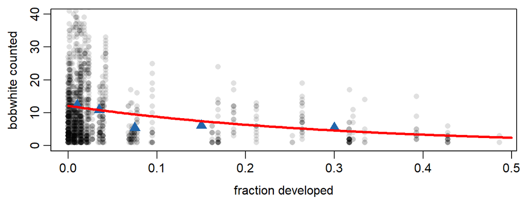

Every 21 percentage points of development costs about half the birds.

## The three count models

```r
year_bob <- bob_all$Year - min(bob_all$Year)

flat <- optimize(function(s){
  -sum(dnbinom(y_bob, mu = mean(y_bob), size = s, log = TRUE))
}, interval = c(0.05, 50))

trend <- optim(par = c(mu0 = 15, decline = 0.03, size = 1),
               fn = function(p){
                 mu <- p["mu0"] * (1 - p["decline"])^year_bob
                 -sum(dnbinom(y_bob, mu = mu, size = p["size"], log = TRUE))
               },
               method = "L-BFGS-B",
               lower = c(0.1, -0.5, 0.05), upper = c(100, 0.5, 50))

round(c(flat = flat$objective, year = trend$value, development = fit_urban$value), 1)
```

```
       flat        year development
     4626.8      4595.6      4574.1
```

Equal parameter counts for the last two, so the lower one simply wins.

But `frac_built` does not change over the 23 years, so it describes **where** the birds are, not **why** they declined.

## Additional practice: reef richness

```r
reef <- read.csv("https://github.com/bmaitner/biometry_course/raw/refs/heads/main/data/Reef_fish/NCRMP_reef_fish_surveys.csv")

depth <- reef$DEPTH
rich <- reef$species_richness

var(rich) / mean(rich)        # overdispersed, so negative binomial
```

```
[1] 4.43347
```

```r
reef_nll <- function(peak, opt, width, size){
  mu <- peak * exp(-(depth - opt)^2 / (2 * width^2))
  -sum(dnbinom(rich, mu = mu, size = size, log = TRUE))
}

fit_reef <- optim(par = c(peak = 25, opt = 20, width = 15, size = 10),
                  fn = function(p){
                    reef_nll(p["peak"], p["opt"], p["width"], p["size"])
                  },
                  method = "L-BFGS-B",
                  lower = c(1, 0, 1, 0.1), upper = c(200, 60, 200, 1000))

round(fit_reef$par, 2)
```

```
 peak   opt width  size
24.72 16.10 24.19  6.50
```

## Does the curve match the cloud?

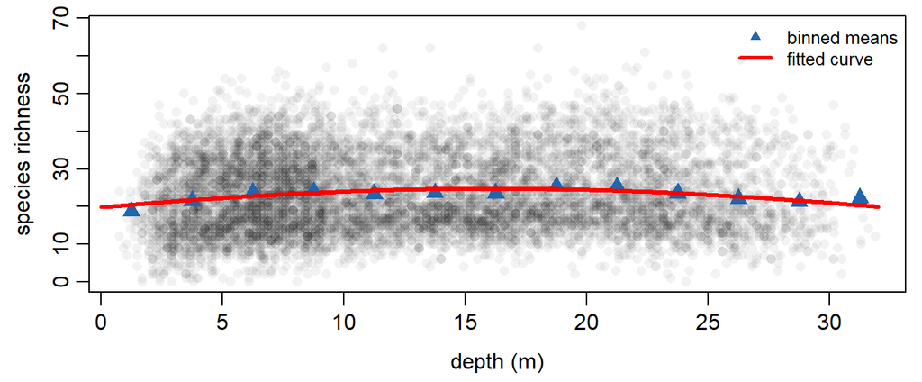

```r
flat_reef <- optimize(function(s){
  -sum(dnbinom(rich, mu = mean(rich), size = s, log = TRUE))
}, interval = c(0.1, 1000))

round(c(hump = fit_reef$value, flat = flat_reef$objective), 1)
```

```
   hump    flat
31752.3 31799.0
```

An optimum near **16 m**, but a width of **24 m**: real, and very gentle.

## What to take away

1. A parameter can be a **function of a covariate**. Nothing else changes.
2. Constrained parameters get **transformed**, so the optimizer cannot wander anywhere illegal.
3. Interpret the estimate **on the scale you fitted it**: log odds, or logs.
4. **Check it**: against a second route to the same fit, and against a plot.